# VARIANTES ALEATORIAS

# variable

$$\begin{cases}
A & 100\\
S & 50
\end{cases}$$

# Tipos

Existen tres tipos y son:

- Continuas
- Discretas
- Mixtas

Las variales aleatorias continuas tiene un numero infinito de elementos, mientras que las discretas tiene un numero finito contable de elementos. La variable mixta, es una combinacion de variable aleatoria continua y discreta.

# Distribucciones

las variabnles aleatorias se pueden caracterizar mediante dos funciones; la funcion de distribuccion acumulativa; $F_X(x)$ y la funcion de densidad. $f_x(x)$

## La funcion de distribuccion acumulativa

La funcion de distribuccion acumulativa se define como:
$$F_X(x) = P_r\{X \le x\}$$
Ademas, cumple con las siguientes propiedades
$$O\le F_X(x) \le 1\\
\mbox{Si}\; a < b, F_X(a) \le F_X(b)\\
F_X(\infty) = 1$$
En `R`, Generamos distribucion usando los comandos :

- `binom` variable aleatoria binomial
- `norm` variable aleatoria normal o Gussiana
- `pois` variable aleatoria Poison
- `exp` variable aleatoria exponencial

y anteponiendole un `p`, por ejemplo :

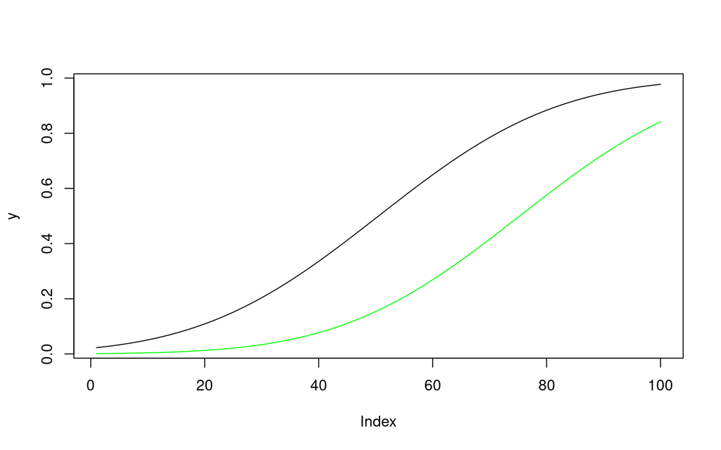

```r
x <- seq(-4, 4, length=100)
y <- pnorm(x, mean=0, sd =2)
y1 <- pnorm(x, mean=2, sd =2)
plot(y, type= "l")
lines(y1, col= "green")
```

## La funcion de densidad de probabilidades (PDF)

La funcion de densidad de probabilidad, $f_X(x)$, se define como
$$f_X(x) = \frac{d}{dx} \left\{ F_X(x)\right\}$$
De la misma manera que la distribuccion ($F_X(x)$), la densidad ($f_X(x)$), se puede generar mediante los comandos `binom`, `norm`, `exp`, etc. anteponiendo una `d`, por ejemplo `dbinom`, `dexp`, etc.

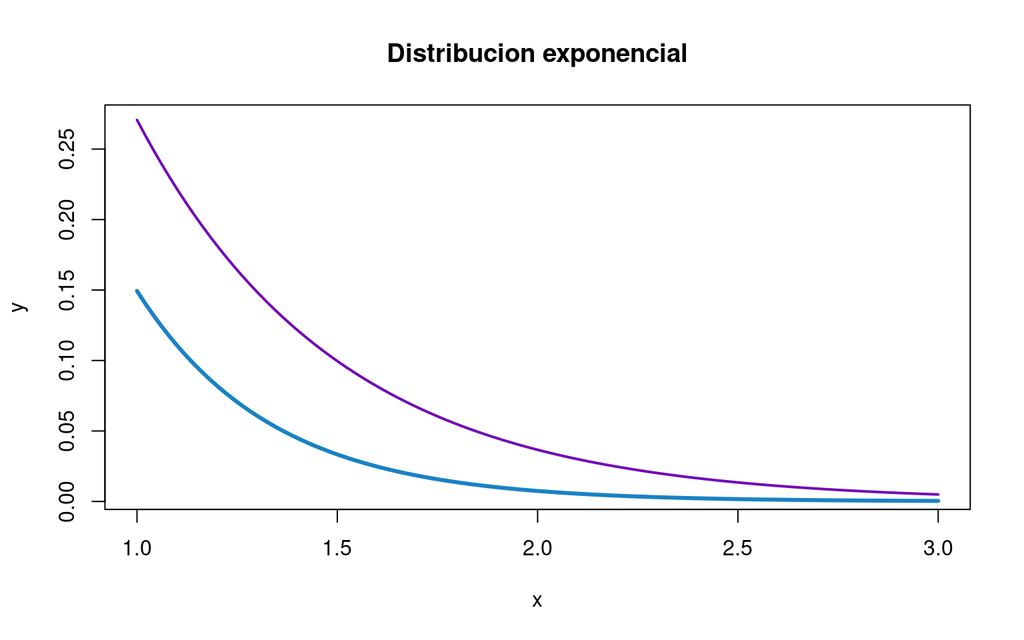

```r
x <- seq(1,3, length = 100)
y <- dexp(x, rate = 2)
y1 <- dexp(x, rate = 3)
plot(x,y, type = "l", col ="#7209b7",lwd = 2, main= "Distribucion exponencial")
lines(x,y1, col ="#1982c4", lwd = 3)
```

## Generacion de valores de las variables aleatorias

Para generar valores de una distribucion usando `R`, anteponemos la letra `r` antes de cualquier nombre de distribucion o densidad, por ejemplo `rbinom`, `rnorm`, etc.

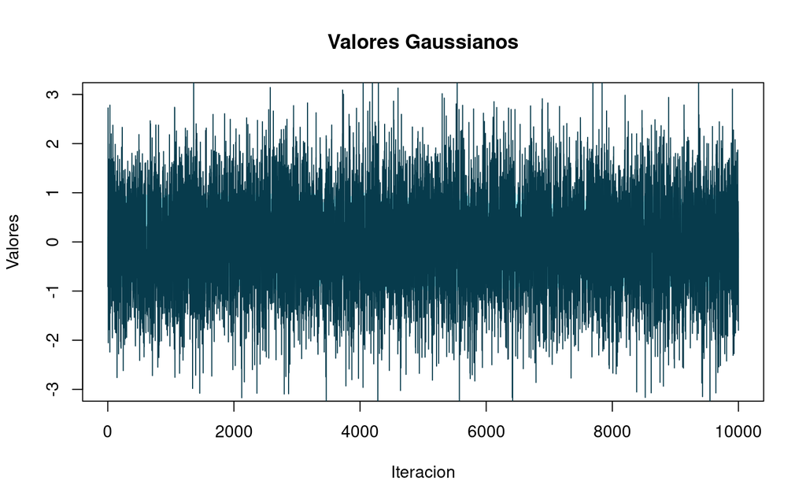

```r
 valores <- rnorm(10000)
 uniforme <- runif(10000, -1,1)
 plot(uniforme, type="l", col="#9bf6ff", main="Valores Gaussianos", xlab="Iteracion",ylab="Valores", ylim =c(-3,3))
 lines(valores, col ="#073b4c")
```

## Momentos de las funciones de densidad

Caracterizan la posicion, ancho, asimetria y picudez de una densidad $f_X(x)$. Entre los momentos mas conocidos:

- Media
- Varianza
- Asimetria

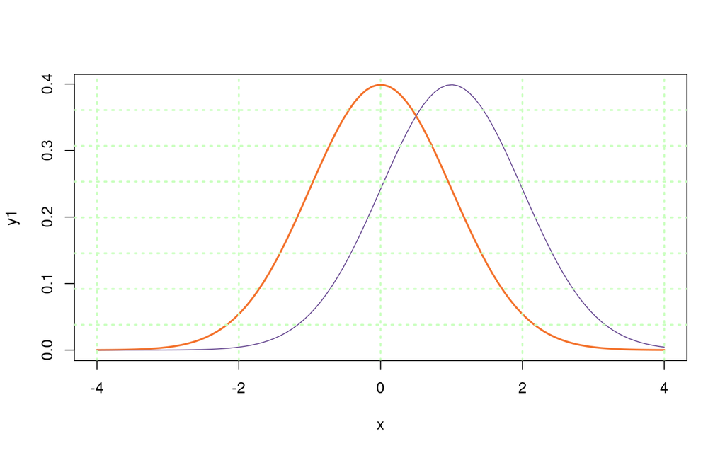

```r
x <- seq(-4,4,length=100)
y1 <- dnorm(x, mean=0, sd=1)
y2 <- dnorm(x, mean=1, sd=1)
plot(x,y1, type="l",col="#f3722c",lwd=2)
lines(x,y2, col="#6a4c93")
grid(col = "#caffbf",lwd=2,lty = "dotted", ny= 8)
```

Para la varianza se tiene:

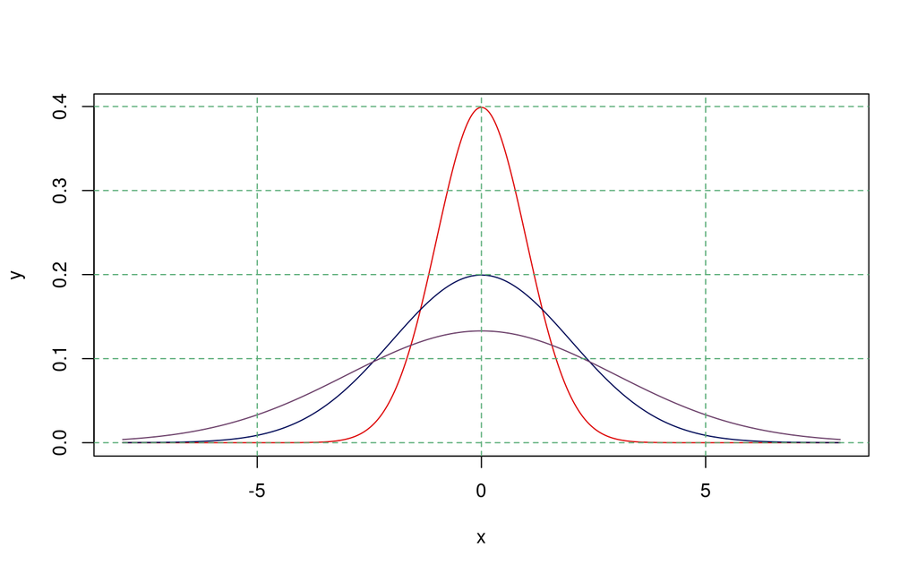

```r
x <- seq(-8,8,length=1000)
y <- dnorm(x,mean=0, sd=1)
y2 <- dnorm(x, sd=2)
y3 <- dnorm(x, sd=3)
plot(x,y,type="l", col="#DD0303")
lines(x,y2, col="#000B58")
lines(x,y3, col="#6B3F69")
grid(col="#59AC77", lty="dashed")
```

### Momentos en el origen

Los momentos en el Origen se definen como:

$$\mathbb{E}\left\{X^n\right\} =
\begin{cases}
\sum_j{X_j^n P(X=x_j)} & \mbox{si es discreto}\\
\int_{\mathbb{R}}{x^nf_X(x)\ dx} & \mbox{si es continuo}
\end{cases}$$

### Momentos centrales

Los momentos centrales se definen como:

$$\mathbb{E}\left\{(X-\mu)^n\right\} =
\begin{cases}
\sum_j{(x_j-\mu)^n P(X=x_j)} & \mbox{si es discreto}\\
\int_{\mathbb{R}}{(x-\mu)^nf_X(x)\ dx} & \mbox{si es continuo}
\end{cases}$$

Donde $\mu$ es el momento con respecto al origen de orden $1$. para $n=2$, tenemos la varianza.

```r
set.seed(100)
x <-  rnorm(n = 1000000)
mean(x)
```

```
## [1] 0.001420706
```

```r
var(x)
```

```
## [1] 0.9982819
```

```r
sd(x)
```

```
## [1] 0.9991406
```

### LA VARIABLE ALEATORIA EXPONENCIAL

La variable aleatoria exponencial describe el tiempo que transcurre hasta que ocurre un evento en un proceso de Poisson, es decir, un proceso donde los eventos ocurren de forma continua e independiente a una tasa promedio constante. Un ejemplo clasico es el tiempo hasta que una particula radiactiva se desintegra o el tiempo hasta que llega el proximo cliente a una tienda.

Esta definida por un unico parametro $(\lambda)$ (lambda), conocido como el parametro de tasa (rate parameter), que representa el numero promedio de eventos que ocurren por unidad de tiempo.

# Formulas principales

### Funcion de Densidad de Probabilidad (PDF)

La PDF nos da la probabilidad relativa de que el evento ocurra en un momento exacto. Para una variable aleatoria exponencial $X ~ {\sim Exp(\lambda)}$, su PDF es:
$$f(x; \lambda) = \begin{cases}
\lambda e^{-\lambda x} & \text{si } x \ge 0 \\
0 & \text{si } x < 0
\end{cases}$$

### Funcion de Distribucio Acumulada (CDF)

La CDF nos da la probabilidad de que el evento ocurra en o antes de un tiempo x . Su formula es:
$$F(x; \lambda) = \begin{cases}
1 - e^{-\lambda x} & \text{si } x \ge 0 \\
0 & \text{si } x < 0
\end{cases}$$

Donde:

$(x)$: es el valor de la variable aleatoria (tiempo).

$(\lambda)$: (λ>0) Es el parametro de tasa

$(e)$ : es la base del logaritmo natural.

# GRAFICO Y VARIACION DEL PARAMETRO λ

El parametro λ controla la forma de la curva de la funcion de densidad.

Si $(\lambda)$ es grande: Significa que los eventos ocurren con mucha frecuencia, poor lo tanto, la probabilidad de que el evento ocurra en un tiempo corto es muy alta, y la curva de la PDF cae muy rapidamente

Si $(\lambda)$ es pequeño: Significa que los eventos son mas raros. La probabilidad se distribuye a lo largo de un periodo de tiempo mas largo, y la curva de la PDF cae mas lentamente.

Aqui tienes un grafico que ilustra como varia la PDF para diferentes valores de $(\lambda)$ :

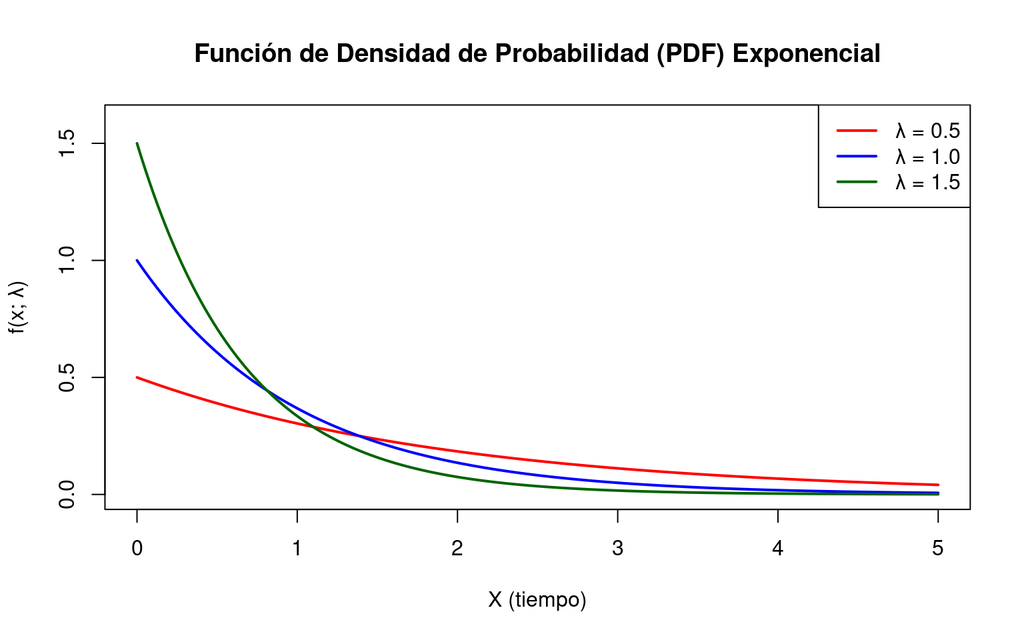

```r
lambdas <- c(0.5, 1, 1.5)
x <- seq(0, 5, length.out = 200)
plot(x, dexp(x, rate = lambdas[1]), type = "l", lwd = 2,
     col = "red", ylim = c(0, 1.6),
     xlab = "X (tiempo)", ylab = "f(x; λ)",
     main = "Función de Densidad de Probabilidad (PDF) Exponencial")
lines(x, dexp(x, rate = lambdas[2]), col = "blue", lwd = 2)
lines(x, dexp(x, rate = lambdas[3]), col = "darkgreen", lwd = 2)
legend("topright",
       legend = c("λ = 0.5", "λ = 1.0", "λ = 1.5"),
       col = c("red", "blue", "darkgreen"),
       lwd = 2)
```

### LA DISTRIBUCION UNIFORME CONTINUA

La distribucion uniforme continua es la mas simple de todas las distribuciones de probabilidad. Describe una situacion en la que todos los resultados dentro de un intervalo especifico son igualmente probables. Es como lanzar un dardo a una linea: la probabilidad de que caiga en cualquier punto es la misma, siempre que esta dentro de los lImites. ????

Esta definida por dos parametros $a$ y $b$ , que representan el valor minimo y maximo del intervalo.

# Formulas principales

Funcion de Densidad de Probabilidad

La PDF de una distribuccion uniforme es una funcion constante dentro del intervalo [$a$,$b$] y cero en cualquier otro lugar. Esto refleja que la probabilidad es la misma para todos los valores dentro del intervalo.

$$f(x) = \begin{cases}
\frac{1}{b - a} & \text{para } a \le x \le b \\
0 & \text{para } x < a \text{ o } x > b
\end{cases}$$

Funcion de Distribuccion Acumulada (CDF)

La CDF describe la probabilidad de que la variable aleatoria tome un valor menor o igual a $x$. Crece linealmente desde 0 hasta 1 dentro del intervalo [$a$,$b$]

$$F(x) = \begin{cases}
0 & \text{para } x < a \\
\frac{x - a}{b - a} & \text{para } a \le x \le b \\
1 & \text{para } x > b
\end{cases}$$
Donde:

$x$ es el valor de la variable aleatoria.

$a$ es el limite inferior del intervalo (minimo)

$b$ es el limite superior del intervalo (maximo)

### Graficos y Variacion de los parametros

Los parametros $a$ y $b$ definen complentamente la distribuccion:

- El Intervalo [$a$,$b$] determina la “posicion” y la anchura” de la distribuccion en el eje horizontal
- La altura de la PDF $\frac{1}{b-a}$, es inversamente proporcional a la anchura del intervalo. Un intervalo mas ancho significa una altura menor, ya que la probabilidad total (el area) debe seguir siendo 1

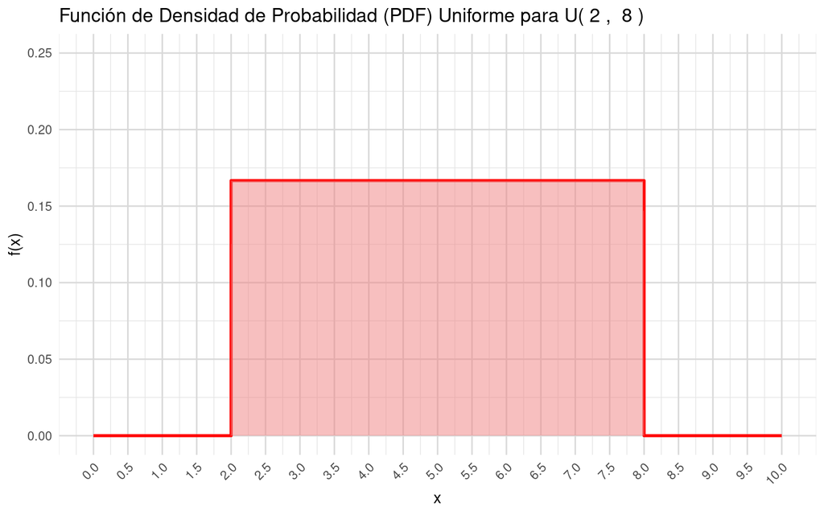

```r
library(ggplot2)

a <- 2
b <- 8
pdf_height <- 1 / (b - a)

data_pdf <- data.frame( x = c(0, a, a, b, b, 10), y = c(0, 0, pdf_height, pdf_height, 0, 0) )

ggplot(data_pdf, aes(x = x, y = y)) +
  geom_line(color = "red", size = 1) +
  geom_area(fill = "lightcoral", alpha = 0.5) +
  labs(
  title = paste("Función de Densidad de Probabilidad (PDF) Uniforme para U(", a, ", ", b, ")"),
  x = "x",
  y = "f(x)"
  ) +
  scale_y_continuous(limits = c(0, 0.25), breaks = seq(0, 0.25, by = 0.05)) +
  scale_x_continuous(limits = c(0, 10), breaks = seq(0, 10, by = 0.5)) +
  theme_minimal() +
  theme( panel.grid.major = element_line(color = "gray85", size = 0.5),
         panel.grid.minor = element_line(color = "gray90", size = 0.25),
         axis.text.x = element_text(angle = 45, hjust = 1)
         )
```

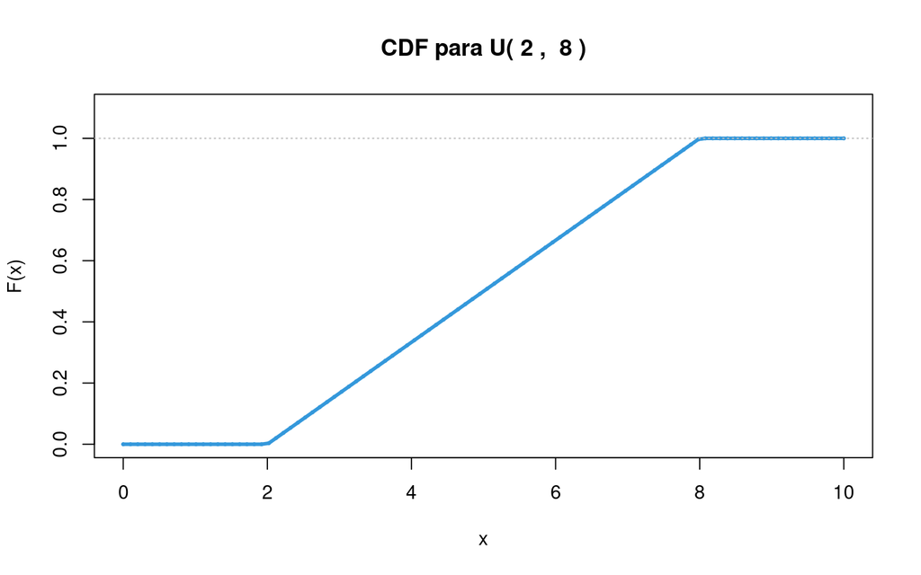

```r
a <- 2
b <- 8

x <- seq(0, 10, length.out = 100)
y <- punif(x, min = a, max = b)

plot(x, y,
     type = "l",
     lwd = 3,
     col = "#3498db",
     ylim = c(0, 1.1),
     main = paste("CDF para U(", a, ", ", b, ")"),
     xlab = "x",
     ylab = "F(x)"
)

points(x, y, pch = 20, col = "#3498db", cex = 0.5)
abline(h = 1.0, lty = 3, col = "gray")
```